# dataQAQC

Alene Onion

December 29, 2018

## QAQC overview

The components of our quality review are:

- Laboratory QAQC
  - Checking that laboratory analyses met all internal QAQC checks
- Accuracy
  - Assessing the bias of a method in a given sample matrix Using a sample matrix spike
- Precision
  - Assessing method precision using duplicate samples analyzed from the same date/location
- Equipment Blank exceedances
  - Assessing the influence of field errors using equipment blank samples
- Parameter Pairs
  - Flagging samples where component parameters exceed total concentrations
- Holding time exceedances
  - Flagging samples where holding times were exceeded

The accuracy, precision, and equipment blank assessments are performed on a subset of samples. The errors discovered with these QC assessments are applied to all normal samples. This is done by associating normal samples to those QC samples closest in date/time to each sample.

## Formatting Sample data for analysis

Plotting the sample dates to understand how best to associate them.

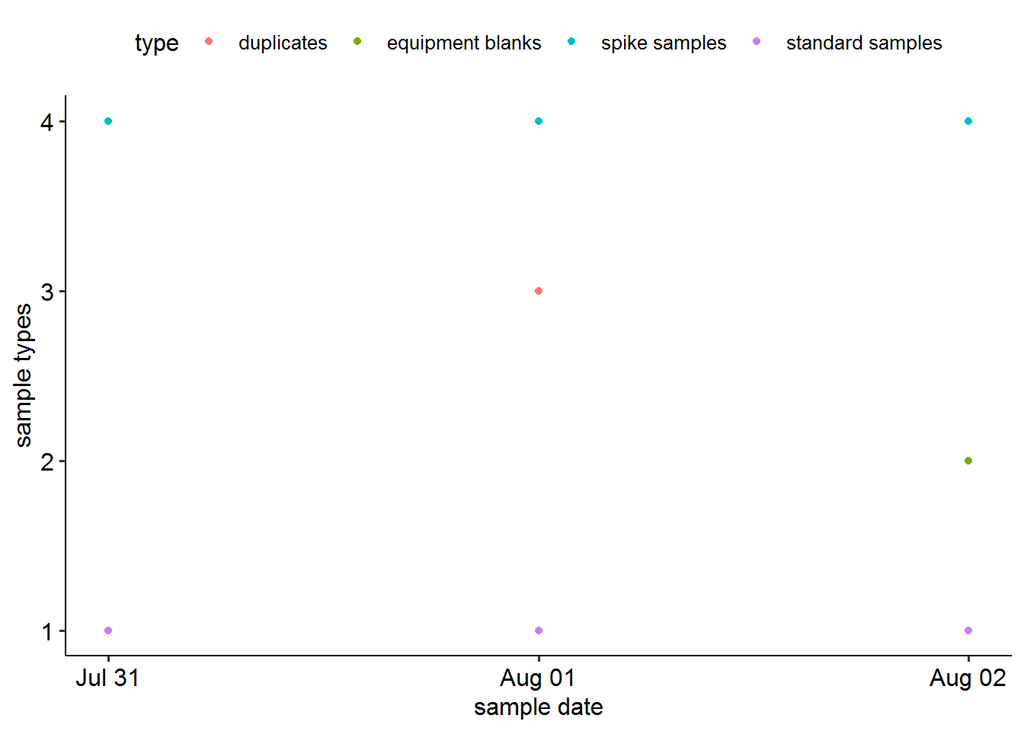

## Laboratory QC

Checking that laboratory analyses met all internal QAQC checks

### Conclusions from the lab reports

NOTE: sometimes a result is flagged * because of a holding time violation which we actually feel is an okay exceedence of HT.

In order to reveiw the narrative reports, you will need the following list of lab_sdg s associated with these data:

|  | lab_sdg | list |
| --- | --- | --- |
| 1 | R1807213 | NA |
| 14 | R1807362 | NA |

Errors noted in the narrative reports:

[output not shown]

### Lab applied flags

The laboratory applied these flags:

|  | lab_qualifiers | present |
| --- | --- | --- |
| 1 |  | present |
| 53 | J | present |
| 76 | U | present |
| 579 | NJ | present |
| 585 | UN | present |
| 599 | N | present |

Which are based on ALS flag codes:

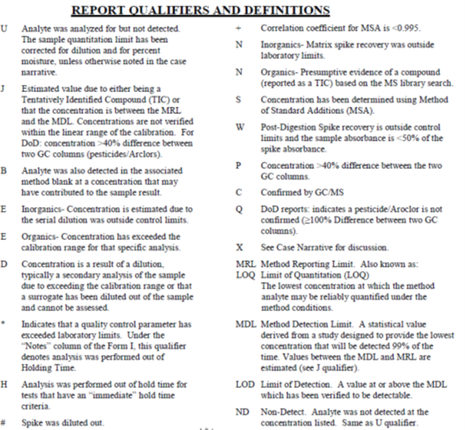

These were converted to simplified flags (in this priority):  
B,N,*,D, or W -> R  
E or J -> J  
U -> U

### Lab Rejected samples

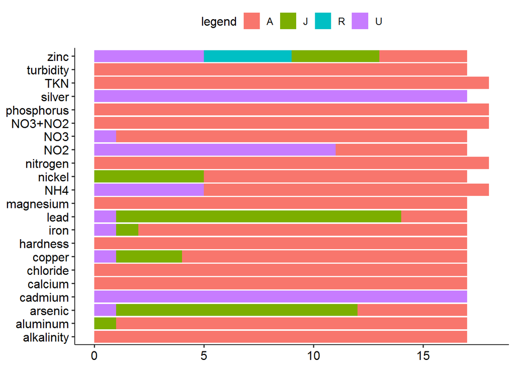

## Accuracy Assessment

- Accuracy
  - A sample matrix spike is used to document the bias of a method in a given sample matrix.
  - Matrix Spike Samples are collected along with regular water quality samples and spiked in the analytic laboratory with a known concentration of analyte. The samples are then analyzed to determine the accuracy (percent recovery) of the analytic results for a given matrix. Spike samples are acceptable if the percent recovery is 100% +/- the accuracy criteria established by the standard methods manual and listed in tables 3 and 4. Otherwise, the spike and it’s associated samples are flagged as rejected, needs verification. Furthermore, if the sample is >4x the spiked amount, the spike assessment is irrelevant and flagged NA.
  - NOTE: the QAPP only requires that we analyze spikes for nutrients, metals and minerals (see section II.5.A.b). I am presuming this excludes solids, turbidity, conductivity, and hardness in addition to in situ parameters, alkalinity, DOC, and chlorophyll a
  - NOTE: we only examine the matrix spike samples. The matrix spike duplicate samples would only be analyzed when we are meausring organics. That’s not the case in any BWAM programs.
  - NOTE: keep in mind that there may be some parameters where samples would be flagged but they shouldn’t be because the spike is diluted even when the sample is <4x the spiked amount.
  - NOTE: Both the laboratory and RoseAnn recommend using higher thresholds for acceptable %recovery than what is listed in the QAPP. Because of this, I have changed the threshold for all parameters except turbidity and chlorophyll to +/- 25% rather than +/-20%.

The accuracy assessments are performed on a subset of samples. The errors discovered with these QC assessments are applied to all normal samples. This is done by associating normal samples to those QC samples closest in date/time to each sample.

### Accuracy Rejected Samples

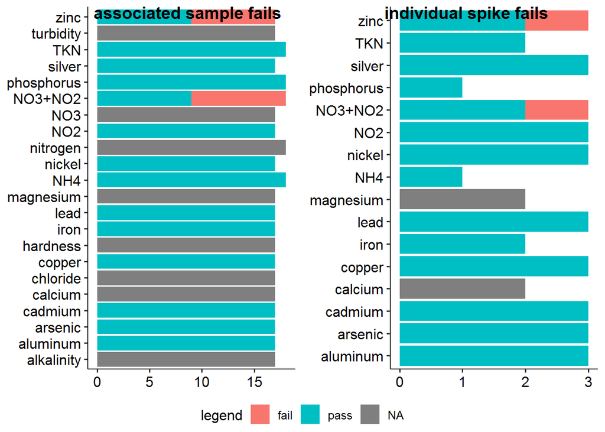

## Precision Assessment

- Precision
  - Duplicate samples are analyzed from the same date/location to assess the method’s precision.
  - Previously, the % difference between these samples must satisfy the precision criteria set forth in table 3 (screening) and table 4 (routine). In this document, we propose using a new method developed by Ohio EPA that offers a curved threshold.

The details of this method are given here: (https://www.epa.ohio.gov/portals/35/documents/sw_samplingmanual.pdf)

In short, they reject any duplicate sample pair where the %RPD > (0.9465x^-0.344)100 +5  
where: x = sample / detection limit %RPD = [diff(duplicate pair)/av(duplicate pair)]*100  
NOTE: I used the maximum of the two samples to calculate x

The precision assessments are performed on a subset of samples. The errors discovered with these QC assessments are applied to all normal samples. This is done by associating normal samples to those QC samples closest in date/time to each sample.

### plots

To examin failures visually, I plotted sample/DL versus %RPD as well as the threshold equation described above.  
Any point above the line should be rejected. Any point below the line is accepted. If the line isn’t visible, that means it is above the range of the graph and all the points would be accepted.  
NOTE: I only plotted parameters that had at least one failed duplicate sample result.

### Precision Rejected Samples

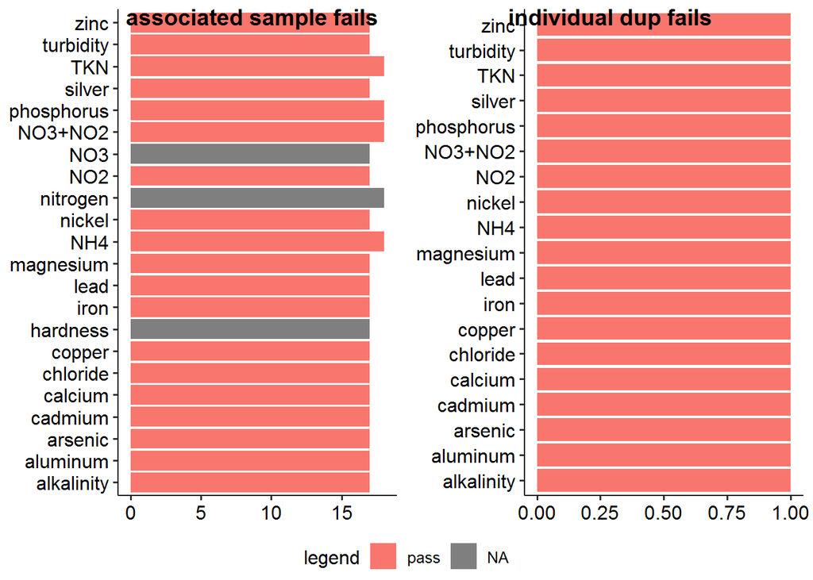

## Equipment Blanks

- Equipment Blank exceedances (result > quantitation limit)
  - Step 1: pull EB values that exceed the quantitation limt
  - Step 2: flag sample values associated with EB exceedences that are less than 10x (flagged estimated), 5x (flagged trend), and 3x (rejected, needs verificaiton) the equipment blank value

IT’S IMPORTANT TO NOTE: that the quantitation limit is NOT the method detection limit. Both are set by the lab and can vary week to week. The quantitation limit is the practical limt the lab was able to achieve and has confidence in on that date.

These flags and their thresholds are again taken from OHIO EPA methods (https://www.epa.ohio.gov/portals/35/documents/sw_samplingmanual.pdf). Their detailed description is replicated below:

| Sample.Result | Interpretation |
| --- | --- |
| Sample <= 3x Blank | Reject sample results in this range as insufficiently different from blank results |
| 3x Blank < Sample <= 5x Blank | Likely indication that the analyte is present but poor confidence in the numerical result - generally limit data use to data “trend” applications |
| < 5x Blank < Sample <= 10x Blank | Consider the sample result to be an estimated concentration (qualified “J”) but still suitable for most data uses |
| < 10x Blank | Do not qualify data (blank contamination does not significantly change the result within the uncertainty of the value reported) |

The equipment blank assessments are performed on a subset of samples. The errors discovered with these QC assessments are applied to all normal samples. This is done by associating normal samples to those QC samples closest in date/time to each sample.

### plots

I only plotted parameters with EB failures.  
The purpose of these plots is to see whether the failures were outliers or were part of an underlying noise. If the latter, then we should consider raising the reporting limit.  
NOTE: I turn non-detects into 0 which I know they are not but for the purpose of identifying failed EBs, I feel this is ok.

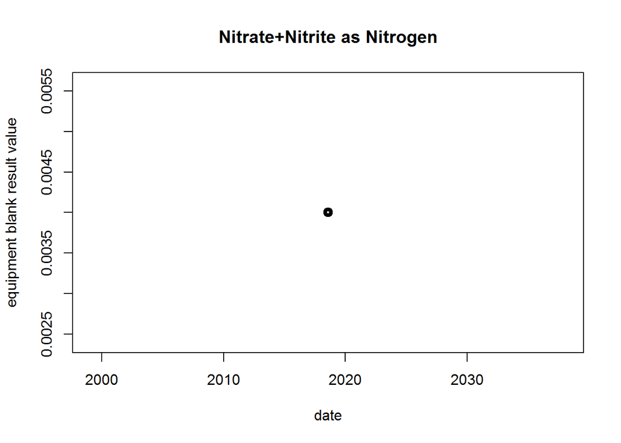

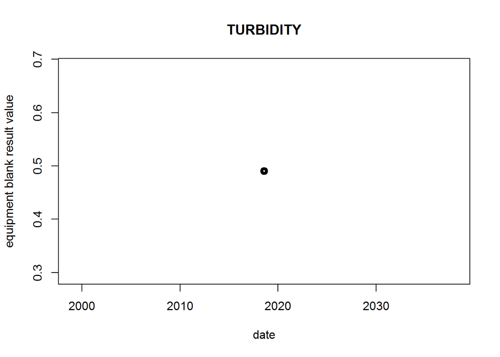

### Equipment Blank Rejected Samples

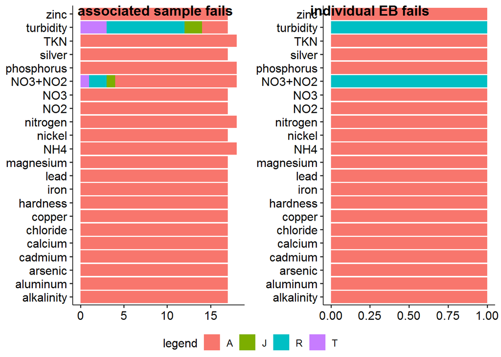

## Parameter Pairs

Parameter Pairs where A is the total and B is the component, B should not be > A

The pairs we examined were as follows:

| component | of |
| --- | --- |
| NITROGEN, NITRATE (AS N) | Nitrate+Nitrite as Nitrogen |
| NITROGEN, NITRITE | Nitrate+Nitrite as Nitrogen |
| Nitrate+Nitrite as Nitrogen | Nitrogen |
| Nitrogen, ammonia (As N) | Nitrogen |
| NITROGEN, KJELDAHL, TOTAL | Nitrogen |
| Orthophosphate as Phosphorus, Dissolved | PHOSPHORUS, TOTAL (AS P) |

### Paired Rejected sampes

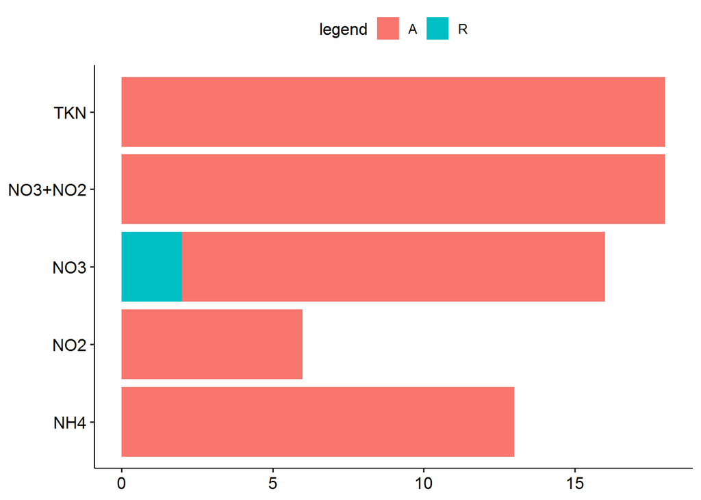

## Holding Time

The analysis date - sample date should not exceed holding time limits held in the holding.times look up table

### Holding Time Rejected samples

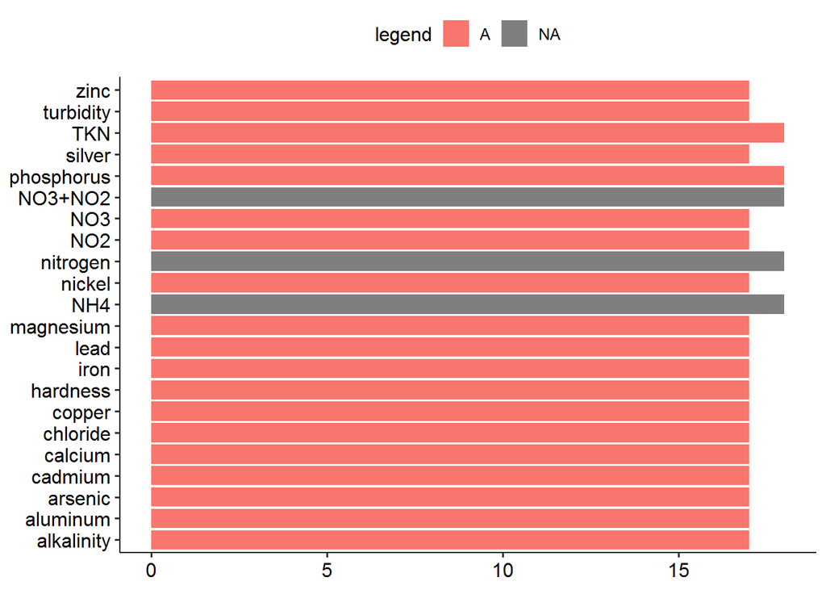

## Summary of QAQC Results

### Reminder of QAQC overview

The components of our quality review are:

- Laboratory QAQC
  - Checking that laboratory analyses met all internal QAQC checks
- Accuracy
  - Assessing the bias of a method in a given sample matrix Using a sample matrix spike
- Precision
  - Assessing method precision using duplicate samples analyzed from the same date/location
- Equipment Blank exceedances
  - Assessing the influence of field errors using equipment blank samples
- Parameter Pairs
  - Flagging samples where component parameters exceed total concentrations
- Holding time exceedances
  - Flagging samples where holding times were exceeded

The accuracy, precision, and equipment blank assessments are performed on a subset of samples. The errors discovered with these QC assessments are applied to all normal samples. This is done by associating normal samples to those QC samples closest in date/time to each sample.

### Flagged Samples

The data flags applied:

| Flag | description |
| --- | --- |
| A | Accepted data |
| J | Consider the sample result to be an estimated concentration but still suitable for most data uses |
| trend | Likely indication that the analyte is present but poor confidence in the numerical result - generally limit data use to data trend applications |
| U | Analyte was analyzed for but not detected |
| R | Rejected samples need verification |

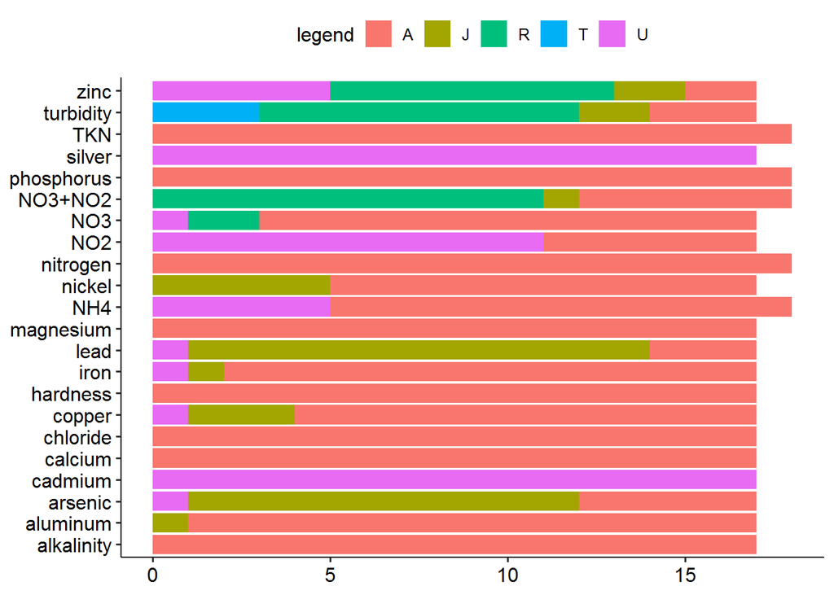

### Interpreted Flags

Plotting the interpreted flags to see the reason the data were flagged

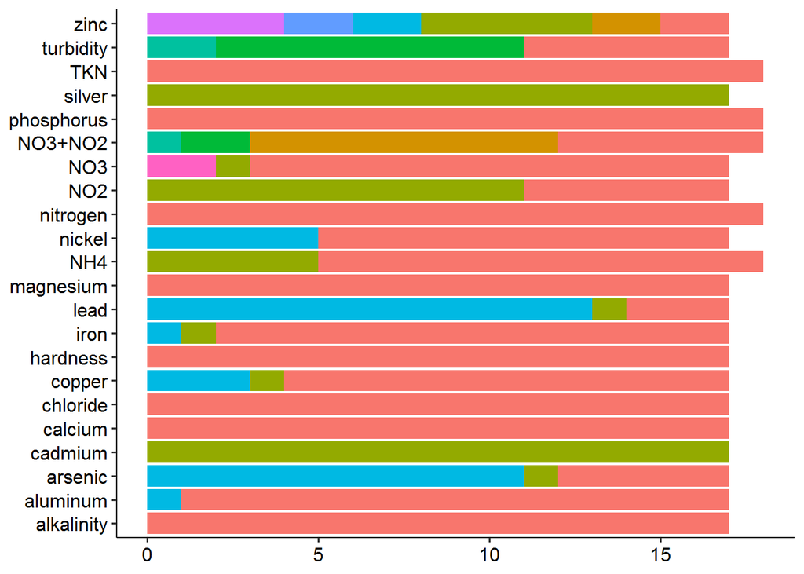

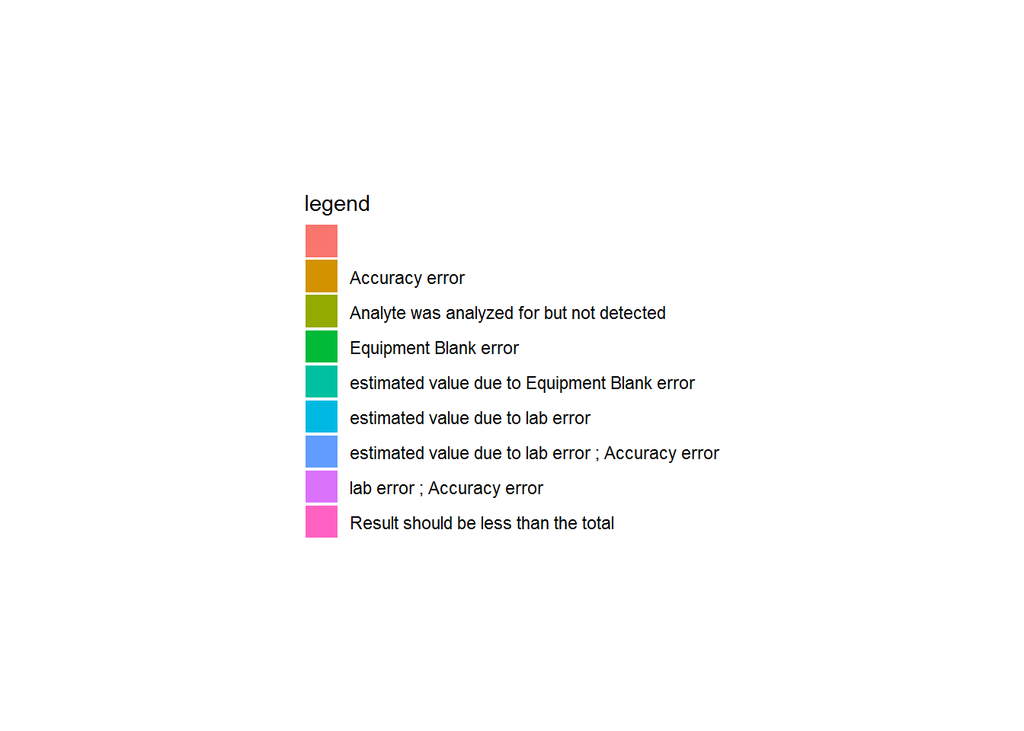